# Algoritma SOM Dengan R

# Algoritma SOM

Self-Organizing Map (SOM) atau sering disebut topology-preserving map pertama kali diperkenalkan oleh Teuvo Kohonen pada tahun 1996 dengan teknik pelatihan ANN yang menggunakan basis winner takes all, dimana hanya neuron yang menjadi pemenang yang akan diperbaharui bobotnya. SOM merupakan salah satu algoritma clustering yang paling populer dan merupakan salah satu tool visualisasi yang handal untuk memproyeksikan hubungan kompleks dari ruang input berdimensi tinggi ke dalam sebuah ruang berdimensi rendah.

Pada algoritma SOM, vektor bobot untuk setiap unit cluster berfungsi sebagai contoh dari input pola yang terkait dengan cluster itu. Selama proses self-organizing, cluster satuan yang bobotnya sesuai dengan pola vektor input yang paling dekat (biasanya, kuadrat dari jarak Euclidean minimum) dipilih sebagai pemenang.

Algoritma SOM adalah salah satu algoritma unsupervised yang dapat diimplementasikan untuk pengelompokkan data dengan pendekatan algoritma jaringan saraf/neural network.

# Tahapan Algoritma SOM

1. Aktifkan package Class, MASS, dan Kohonen.
2. Memanggil data titanic dalam R.
3. Melakukan standarisasi data.
4. Melihat dimensi dari data titanic.
5. Melihat struktur dari data titanic.
6. Kemudian membuat kelompok atau clustering dari data titanic.
7. Selanjutnya melakukan perintah SOM dari data titanic.
8. Melihat struktur data setelah adanya cara kerja SOM pada data titanic.
9. Melihat hasil plot dari data.
10. Melihat objek yang masuk didalam lingkaran.
11. Melihat letak nomer objek berapa yang masuk dalam lingkaran.
12. Kemudian melihat plot keseluruhan som.titanic dan letak dari masing-masing unit klasifikasi.
13. Selanjutnya melihat hasil pengelompokkan dari beberapa objek didalam masing-masing lingkaran.
14. Melakukan pengelompokkan berdasarkan nilai codes menggunakan cluster hierarki.
15. Kemudian membuat plot hasil pengelompokkan dan menambahkan garis pembatas untuk melihat lebih jelas batas pada pengelompokkan.

# Eksperimen Algoritma SOM

## Library

```r
library(class)
library(MASS)
library(kohonen)
```

## Data

```r
data("Titanic")
View(Titanic)
```

## Standarisasi

```r
scale(Titanic)
```

```
##              [,1]
##  [1,] -0.50575972
##  [2,] -0.50575972
##  [3,] -0.24839902
##  [4,] -0.50575972
##  [5,] -0.50575972
##  [6,] -0.50575972
##  [7,] -0.38075595
##  [8,] -0.50575972
##  [9,]  0.36191347
## [10,]  0.62662733
## [11,]  2.33991421
## [12,]  4.42085923
## [13,] -0.47634706
## [14,] -0.41016860
```

[output cut: 22 more lines]

```r
head(scale(Titanic))
```

```
##            [,1]
## [1,] -0.5057597
## [2,] -0.5057597
## [3,] -0.2483990
## [4,] -0.5057597
## [5,] -0.5057597
## [6,] -0.5057597
```

## Dimensi Data

```r
dim(Titanic)
```

```
## [1] 4 2 2 2
```

## Struktur Data

```r
str(Titanic)
```

```
##  'table' num [1:4, 1:2, 1:2, 1:2] 0 0 35 0 0 0 17 0 118 154 ...
##  - attr(*, "dimnames")=List of 4
##   ..$ Class   : chr [1:4] "1st" "2nd" "3rd" "Crew"
##   ..$ Sex     : chr [1:2] "Male" "Female"
##   ..$ Age     : chr [1:2] "Child" "Adult"
##   ..$ Survived: chr [1:2] "No" "Yes"
```

## Kelompok atau Clustering

```r
grid <- somgrid(xdim=5 , ydim=5 , topo = "hexagonal")
```

```r
som.Titanic<-som(scale(Titanic), grid=somgrid(xdim=5, ydim=5, topo="hexagonal"))
```

```r
str(som.Titanic)
```

```
## List of 14
##  $ data            :List of 1
##   ..$ : num [1:32, 1] -0.506 -0.506 -0.248 -0.506 -0.506 ...
##   .. ..- attr(*, "scaled:center")= num 68.8
##   .. ..- attr(*, "scaled:scale")= num 136
##  $ unit.classif    : num [1:32] 1 1 12 1 1 1 16 1 13 23 ...
##  $ distances       : num [1:32] 9.81e-07 9.81e-07 3.02e-06 9.81e-07 9.81e-07 ...
##  $ grid            :List of 6
##   ..$ pts              : num [1:25, 1:2] 1.5 2.5 3.5 4.5 5.5 1 2 3 4 5 ...
##   .. ..- attr(*, "dimnames")=List of 2
##   .. .. ..$ : NULL
##   .. .. ..$ : chr [1:2] "x" "y"
##   ..$ xdim             : num 5
##   ..$ ydim             : num 5
##   ..$ topo             : chr "hexagonal"
##   ..$ neighbourhood.fct: Factor w/ 2 levels "bubble","gaussian": 1
##   ..$ toroidal         : logi FALSE
##   ..- attr(*, "class")= chr "somgrid"
##  $ codes           :List of 1
##   ..$ : num [1:25, 1] -0.5048 -0.4812 -0.2335 0.0616 0.1284 ...
##   .. ..- attr(*, "dimnames")=List of 2
##   .. .. ..$ : chr [1:25] "V1" "V2" "V3" "V4" ...
##   .. .. ..$ : NULL
##  $ changes         : num [1:100, 1] 0.0203 0.1177 0.0286 0.0857 0.0521 ...
##  $ alpha           : num [1:2] 0.05 0.01
##  $ radius          : Named num [1:2] 3 0
##   ..- attr(*, "names")= chr [1:2] "66.66667%" ""
##  $ na.rows         : int(0)
##  $ user.weights    : num 1
##  $ distance.weights: num 1
##  $ whatmap         : int 1
##  $ maxNA.fraction  : int 0
##  $ dist.fcts       : chr "sumofsquares"
##  - attr(*, "class")= chr "kohonen"
```

## Hasil Plot

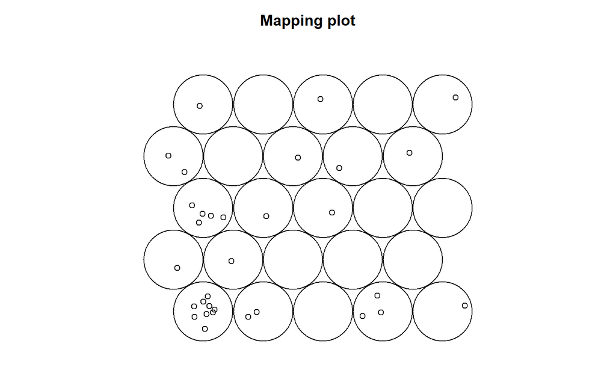

```r
plot(som.Titanic, type="mapping")
```

```r
som.Titanic$grid$pts
```

```
##         x         y
##  [1,] 1.5 0.8660254
##  [2,] 2.5 0.8660254
##  [3,] 3.5 0.8660254
##  [4,] 4.5 0.8660254
##  [5,] 5.5 0.8660254
##  [6,] 1.0 1.7320508
##  [7,] 2.0 1.7320508
##  [8,] 3.0 1.7320508
##  [9,] 4.0 1.7320508
## [10,] 5.0 1.7320508
## [11,] 1.5 2.5980762
## [12,] 2.5 2.5980762
## [13,] 3.5 2.5980762
## [14,] 4.5 2.5980762
## [15,] 5.5 2.5980762
## [16,] 1.0 3.4641016
## [17,] 2.0 3.4641016
## [18,] 3.0 3.4641016
## [19,] 4.0 3.4641016
## [20,] 5.0 3.4641016
## [21,] 1.5 4.3301270
## [22,] 2.5 4.3301270
## [23,] 3.5 4.3301270
## [24,] 4.5 4.3301270
## [25,] 5.5 4.3301270
```

## Letak Nomor Dari Masing-masing Data

```r
som.Titanic$unit.classif
```

```
##  [1]  1  1 12  1  1  1 16  1 13 23 20 25  2 11  5  2  6  7 11  1  1 11 11  1 21
## [26] 11  4 19 18  4  4 16
```

## Letak Masing-masing Unit

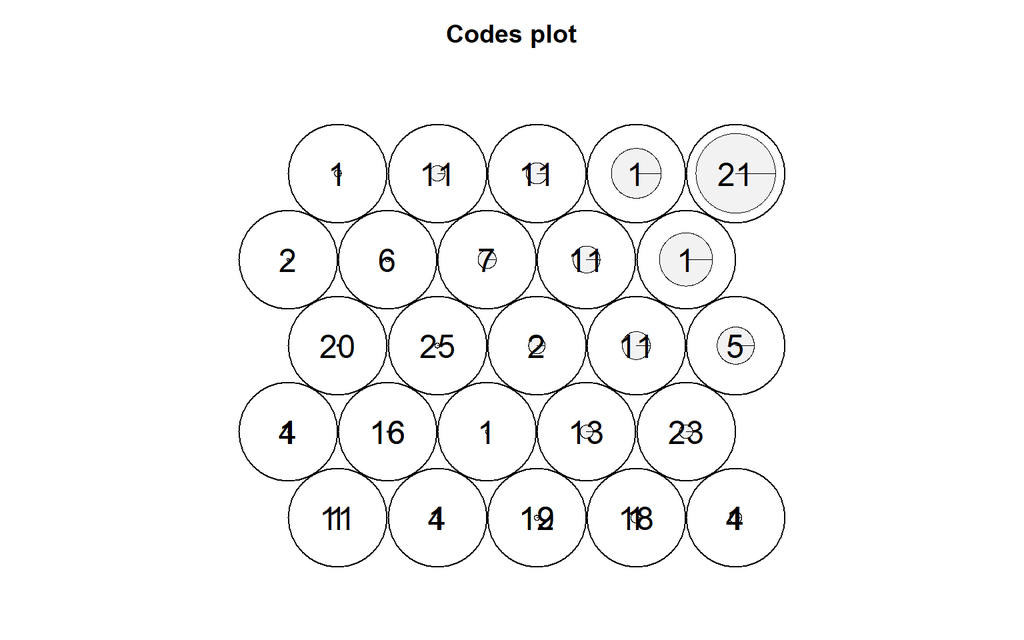

```r
plot(som.Titanic)
text(som.Titanic$grid$pts, labels = som.Titanic$unit.classif,cex=1.5)
```

## Kode Nilai

```r
som.Titanic$codes[[1]]
```

```
##            [,1]
## V1  -0.50476907
## V2  -0.48118510
## V3  -0.23347650
## V4   0.06158698
## V5   0.12842224
## V6  -0.46250970
## V7  -0.43892299
## V8  -0.31590064
## V9   0.19915033
## V10  0.21703210
## V11 -0.40408231
## V12 -0.24666069
## V13  0.37550575
## V14  0.98472089
## V15  1.48222101
## V16 -0.36415055
## V17 -0.25919127
## V18  0.47097909
## V19  0.93292985
## V20  2.33480044
## V21 -0.13974288
## V22  0.31328561
## V23  0.62420271
## V24  2.15533431
## V25  3.74996833
```

## Jarak & Hierarki Pengelompokkan

```r
dist(som.Titanic$codes[[1]])
```

```
##             V1         V2         V3         V4         V5         V6
## V2  0.02358397
## V3  0.27129257 0.24770860
## V4  0.56635605 0.54277208 0.29506348
## V5  0.63319131 0.60960734 0.36189874 0.06683526
## V6  0.04225937 0.01867540 0.22903319 0.52409667 0.59093194
## V7  0.06584608 0.04226211 0.20544649 0.50050997 0.56734523 0.02358671
## V8  0.18886842 0.16528446 0.08242414 0.37748762 0.44432288 0.14660905
## V9  0.70391940 0.68033543 0.43262683 0.13756335 0.07072809 0.66166003
## V10 0.72180117 0.69821720 0.45050861 0.15544513 0.08860986 0.67954180
## V11 0.10068676 0.07710279 0.17060580 0.46566928 0.53250455 0.05842739
## V12 0.25810838 0.23452441 0.01318419 0.30824767 0.37508293 0.21584900
## V13 0.88027482 0.85669085 0.60898225 0.31391877 0.24708351 0.83801545
## V14 1.48948995 1.46590599 1.21819739 0.92313391 0.85629865 1.44723058
## V15 1.98699007 1.96340611 1.71569751 1.42063403 1.35379876 1.94473070
## V16 0.14061852 0.11703455 0.13067405 0.42573753 0.49257279 0.09835915
## V17 0.24557780 0.22199383 0.02571477 0.32077825 0.38761351 0.20331843
## V18 0.97574816 0.95216419 0.70445559 0.40939211 0.34255685 0.93348879
## V19 1.43769892 1.41411495 1.16640635 0.87134287 0.80450761 1.39543955
## V20 2.83956950 2.81598554 2.56827694 2.27321346 2.20637820 2.79731013
## V21 0.36502619 0.34144222 0.09373362 0.20132986 0.26816512 0.32276682
## V22 0.81805467 0.79447070 0.54676211 0.25169863 0.18486336 0.77579530
## V23 1.12897178 1.10538781 0.85767921 0.56261573 0.49578047 1.08671241
## V24 2.66010337 2.63651941 2.38881081 2.09374733 2.02691206 2.61784400
## V25 4.25473739 4.23115343 3.98344483 3.68838135 3.62154608 4.21247802
##             V7         V8         V9        V10        V11        V12
## V2
## V3
## V4
## V5
## V6
## V7
## V8  0.12302234
## V9  0.63807332 0.51505097
## V10 0.65595509 0.53293275 0.01788177
## V11 0.03484068 0.08818166 0.60323264 0.62111441
## V12 0.19226230 0.06923995 0.44581102 0.46369279 0.15742161
## V13 0.81442874 0.69140639 0.17635542 0.15847365 0.77958805 0.62216644
## V14 1.42364387 1.30062153 0.78557056 0.76768878 1.38880319 1.23138158
## V15 1.92114399 1.79812165 1.28307067 1.26518890 1.88630331 1.72888170
```

[output cut: 45 more lines]

```
## V11
## V12
## V13
## V14
## V15
## V16
## V17
## V18
## V19
## V20 1.40187059
## V21 1.07267273 2.47454332
## V22 0.61964425 2.02151483 0.45302849
## V23 0.30872714 1.71059773 0.76394559 0.31091710
## V24 1.22240445 0.17946613 2.29507719 1.84204870 1.53113160
## V25 2.81703847 1.41516789 3.88971121 3.43668272 3.12576562 1.59463402
```

```r
hclust(dist(som.Titanic$codes[[1]]))
```

```
##
## Call:
## hclust(d = dist(som.Titanic$codes[[1]]))
##
## Cluster method   : complete
## Distance         : euclidean
## Number of objects: 25
```

## Cluster Boundaris

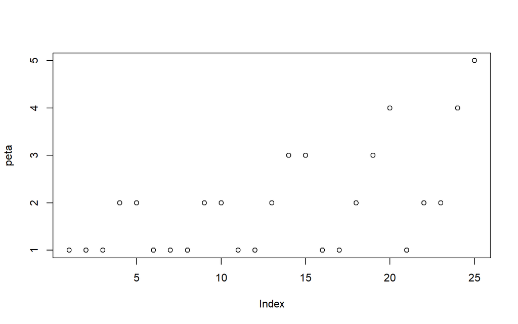

```r
peta <- cutree(hclust(dist(som.Titanic$codes[[1]])),5)
plot(peta)
```

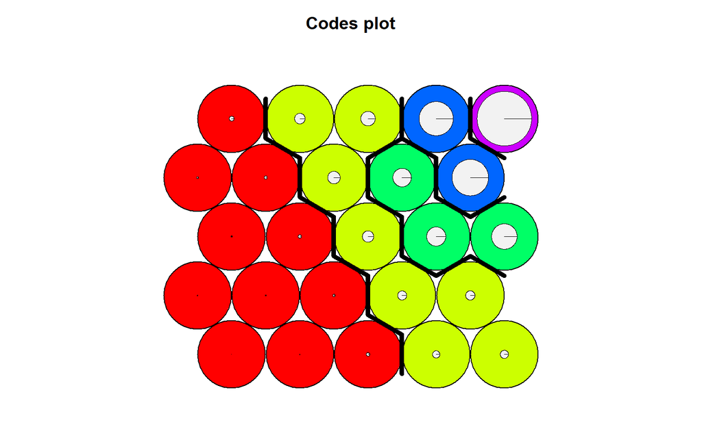

```r
plot(som.Titanic,type="codes",bgcol=rainbow(5)[peta])
add.cluster.boundaries(som.Titanic, peta)
```

# Referensi

1. https://medium.com/@16611130/penerapan-self-organizing-map-som-pada-r-menggunakan-data-wines-7c83130fc1a0
2. Akun Github : https://github.com/zumafikanadila/Algoritma-SOM
3. https://medium.com/@riameliaa25/self-organizing-map-som-dengan-iris-dataset-menggunakan-r-57b77bc2daa7